# Reddy_Vishruth_HW_06

# Categorical and Continuous Variables Relationships Exploration

## Conditional KDE Plots for DF02

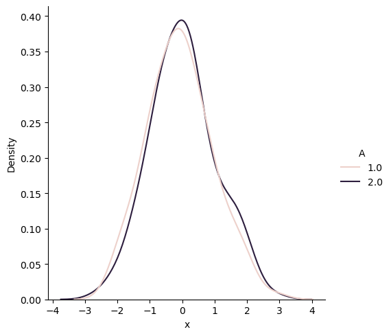

```python
sns.displot(data = df02, x='x', hue='A',
            common_norm=False, kind='kde')

plt.show()
```

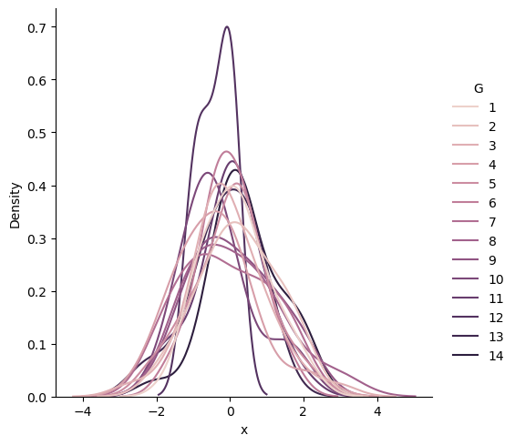

```python
sns.displot(data = df02, x='x', hue='G',
            common_norm=False, kind='kde')

plt.show()
```

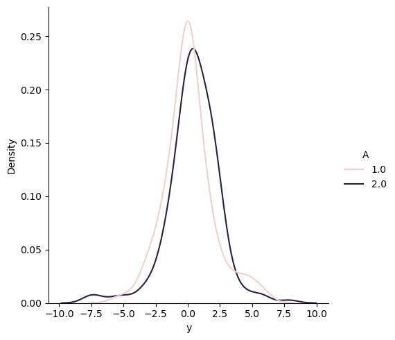

```python
sns.displot(data = df02, x='y', hue='A',
            common_norm=False, kind='kde')

plt.show()
```

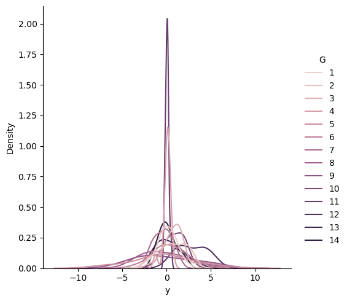

```python
sns.displot(data = df02, x='y', hue='G',
            common_norm=False, kind='kde')

plt.show()
```

## Boxplots for DF02

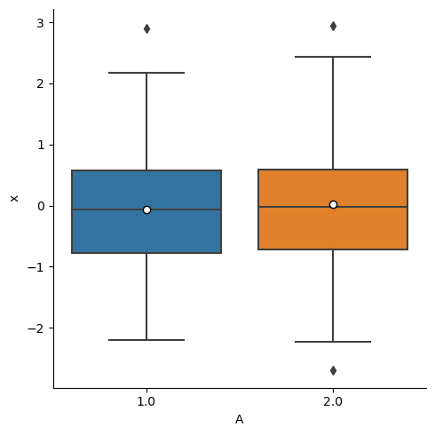

```python
sns.catplot(data = df02, x='A', y='x', kind='box',
            showmeans=True,
            meanprops={'marker': 'o', 'markerfacecolor': 'white', 'markeredgecolor': 'black'})

plt.show()
```

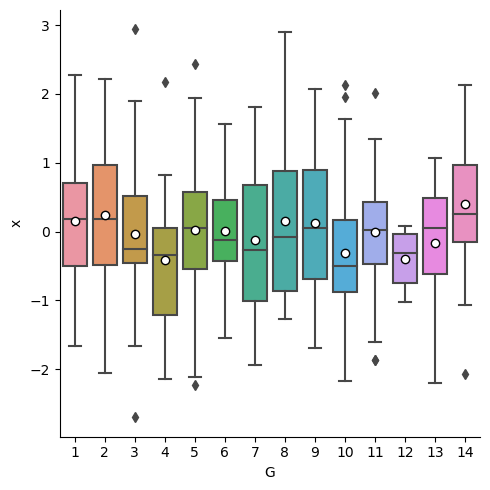

```python
sns.catplot(data = df02, x='G', y='x', kind='box',
            showmeans=True,
            meanprops={'marker': 'o', 'markerfacecolor': 'white', 'markeredgecolor': 'black'})

plt.show()
```

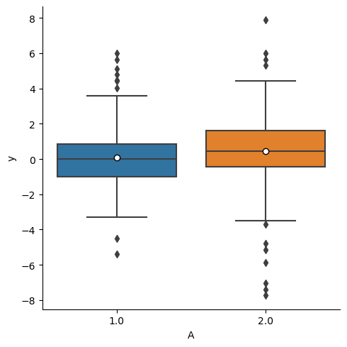

```python
sns.catplot(data = df02, x='A', y='y', kind='box',
            showmeans=True,
            meanprops={'marker': 'o', 'markerfacecolor': 'white', 'markeredgecolor': 'black'})

plt.show()
```

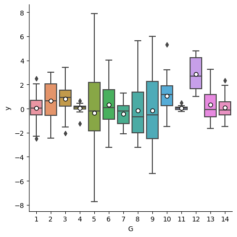

```python
sns.catplot(data = df02, x='G', y='y', kind='box',
            showmeans=True,
            meanprops={'marker': 'o', 'markerfacecolor': 'white', 'markeredgecolor': 'black'})

plt.show()
```

## Point Plots for DF02

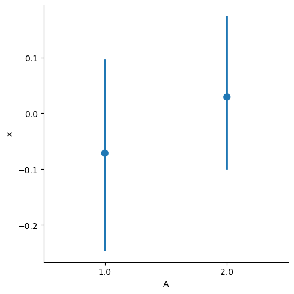

```python
sns.catplot( data = df02, x='A', y='x', kind='point', join=False )

plt.show()
```

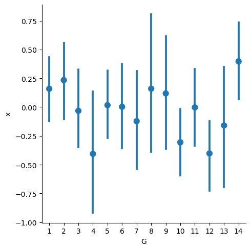

```python
sns.catplot( data = df02, x='G', y='x', kind='point', join=False )

plt.show()
```

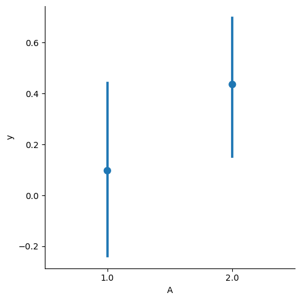

```python
sns.catplot( data = df02, x='A', y='y', kind='point', join=False )

plt.show()
```

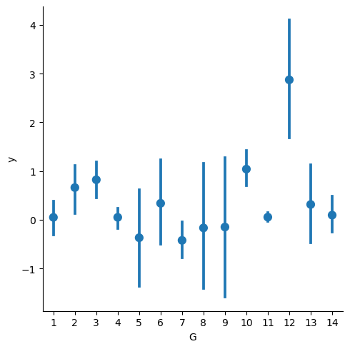

```python
sns.catplot( data = df02, x='G', y='y', kind='point', join=False )

plt.show()
```

## Questions

**Does the distributional SHAPE of a NUMERIC column appear to be different across the CATEGORIES of the NON-NUMERIC column?**

*Yes, the shape is different across the categories of the non-numeric column.*

**Does the MEDIAN of the NUMERIC column appear to be different across the CATEGORIES of the NON-NUMERIC column?**

**Does the VARIATION of the NUMERIC column appear to be different across the CATEGORIES of the NON-NUMERIC column?**

*Yes, the variation is different across the categories of the non-numeric column.*

**Are you confident that the MEAN of the NUMERIC column CHANGES across the CATEGORIES of the NON-NUMERIC column?**

## Problem 03

Read in the `hw05_prob_03.csv` CSV file and assign it to the `df03` object.

Visually explore the `df03` object following **ALL** required actions listed previously.

You must add more code cells and markdown cells to complete this problem.

#### 03) - SOLUTION

```python
df03 = pd.read_csv('hw05_prob_03.csv')
```

```python
df03
```

|  | obs_id | key | value |
| --- | --- | --- | --- |
| 0 | 1 | x1 | 0.034632 |
| 1 | 2 | x1 | 0.523494 |
| 2 | 3 | x1 | 1.224766 |
| 3 | 4 | x1 | 1.517422 |
| 4 | 5 | x1 | 2.432589 |
| ... | ... | ... | ... |
| 1402 | 197 | x7 | -8.145633 |
| 1403 | 198 | x7 | NaN |
| 1404 | 199 | x7 | -8.152787 |
| 1405 | 200 | x7 | -8.063927 |
| 1406 | 201 | x7 | NaN |

1407 rows × 3 columns

```python
df03.info()
```

```
<class 'pandas.core.frame.DataFrame'>
RangeIndex: 1407 entries, 0 to 1406
Data columns (total 3 columns):
 #   Column  Non-Null Count  Dtype
---  ------  --------------  -----
 0   obs_id  1407 non-null   int64
 1   key     1407 non-null   object
 2   value   1379 non-null   float64
dtypes: float64(1), int64(1), object(1)
memory usage: 33.1+ KB
```

```python
df03.nunique()
```

```
obs_id     201
key          7
value     1379
dtype: int64
```

```python
df03.isna().sum()
```

```
obs_id     0
key        0
value     28
dtype: int64
```

```python
df03.key.value_counts()
```

```
x1    201
x2    201
x3    201
x4    201
x5    201
x6    201
x7    201
Name: key, dtype: int64
```

## Bar Charts for DF03

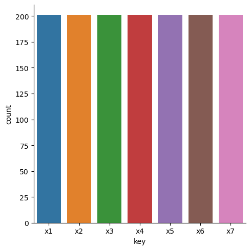

```python
sns.catplot(data = df03, x='key', kind='count')

plt.show()
```

## Histograms for DF03

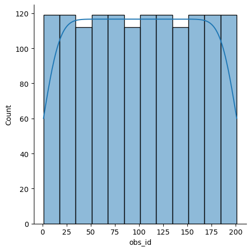

```python
sns.displot( data = df03, x='obs_id', kind='hist', kde=True )

plt.show()
```

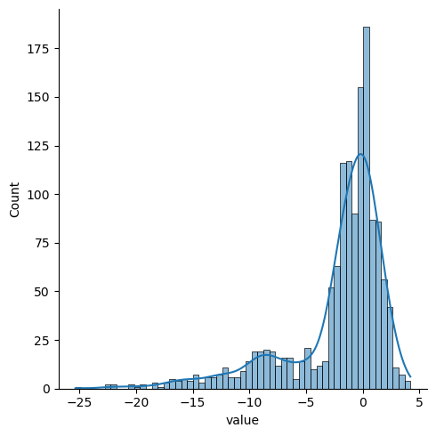

```python
sns.displot( data = df03, x='value', kind='hist', kde=True )

plt.show()
```

## Questions

**Do the categories of the NON-NUMERIC columns have similar counts?**

*Yes, the `key` category has a similar count.*

**Do the histograms of the NUMERIC columns look roughly like bell curves?**

*No, the `obs_id` histogram doesn't look like a bell-curve.*

# Exploration of Combination between 2 non-numeric columns

## Dodged Bar Charts for DF03

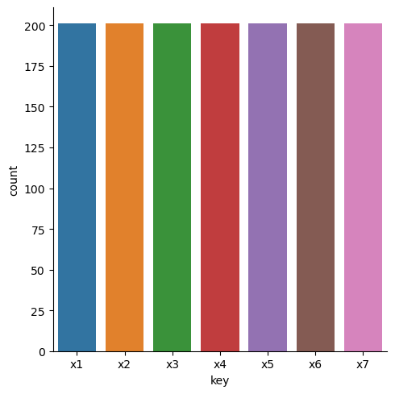

```python
sns.catplot( data = df03, x='key', kind='count' )

plt.show()
```

*Combining 2 non-numeric columns isn't possible for `df03` as there is only 1 non-numeric value. Hence, creating a dodged bar chart didn't yield a different graph as compared to a normal bar chart*

## Heat Maps for DF03

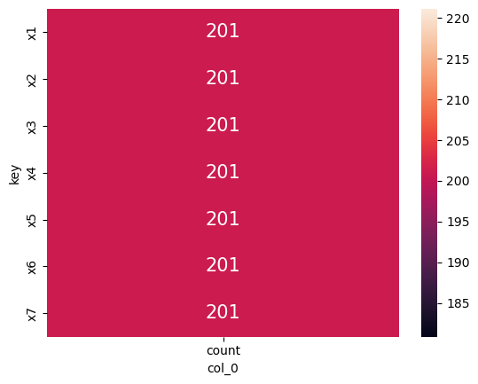

```python
fig, ax = plt.subplots()

# sns.heatmap( pd.crosstab( df03.key ), ax = ax,
#              annot=True, annot_kws={'size': 20}, fmt='d')

sns.heatmap( pd.crosstab(df03.key, columns='count'), ax = ax,
             annot=True, annot_kws={'size': 15}, fmt='d')

plt.show()
```

## Questions

**Are there combinations between the 2 variables NOT present in the data?**

*There are no missing combinations as there is only 1 non-numeric column.*

**Which plot type was it easier to identify combinations that were NOT present?**

*It is ideally better to find the missing combinations in heat maps due to the numbers being displayed in the box. In this example, there are no missing combinations.*

# Categorical and Continuous Variables Relationships Exploration

## Conditional KDE Plots for DF03

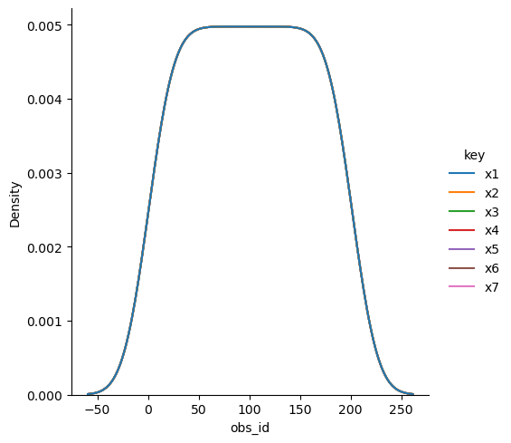

```python
sns.displot(data = df03, x='obs_id', hue='key',
            common_norm=False, kind='kde')

plt.show()
```

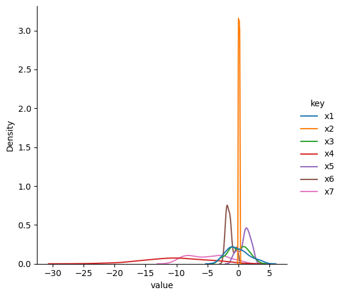

```python
sns.displot(data = df03, x='value', hue='key',
            common_norm=False, kind='kde')

plt.show()
```

## Boxplots for DF03

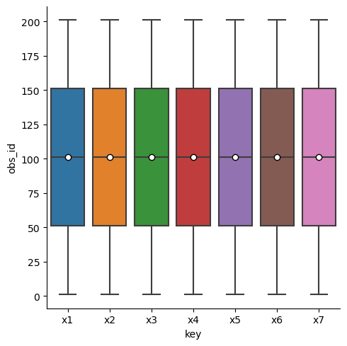

```python
sns.catplot(data = df03, x='key', y='obs_id', kind='box',
            showmeans=True,
            meanprops={'marker': 'o', 'markerfacecolor': 'white', 'markeredgecolor': 'black'})

plt.show()
```

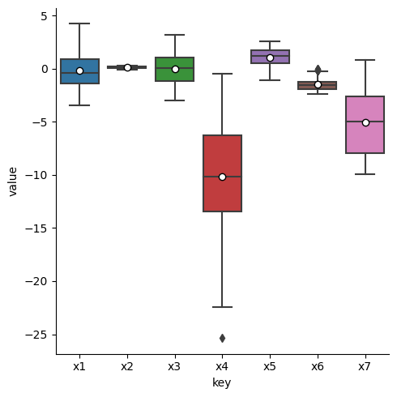

```python
sns.catplot(data = df03, x='key', y='value', kind='box',
            showmeans=True,
            meanprops={'marker': 'o', 'markerfacecolor': 'white', 'markeredgecolor': 'black'})

plt.show()
```

## Point Plots for DF03

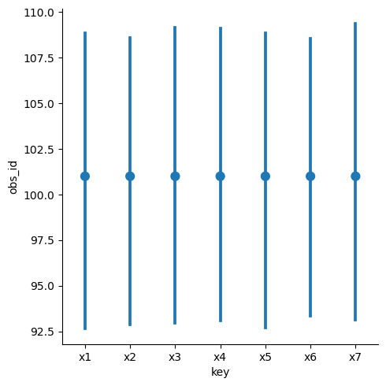

```python
sns.catplot( data = df03, x='key', y='obs_id', kind='point', join=False )

plt.show()
```

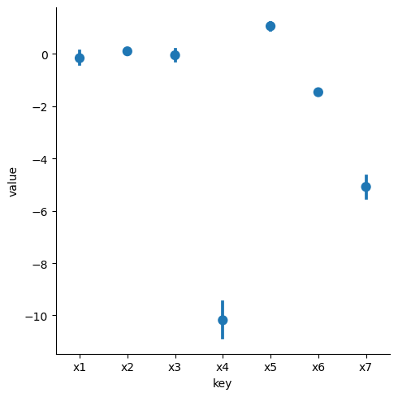

```python
sns.catplot( data = df03, x='key', y='value', kind='point', join=False )

plt.show()
```

## Questions

**Does the distributional SHAPE of a NUMERIC column appear to be different across the CATEGORIES of the NON-NUMERIC column?**

*No, the shape is the same across `key` and `obs_id`.*

*Yes, the shape is different across `key` and `value`.*

**Does the MEDIAN of the NUMERIC column appear to be different across the CATEGORIES of the NON-NUMERIC column?**

*No, the median is the same across `key` and `obs_id`.*

*Yes, the median is different across `key` and `value`.*

**Does the VARIATION of the NUMERIC column appear to be different across the CATEGORIES of the NON-NUMERIC column?**

*No, the variation is the same across `key` and `obs_id`.*

*Yes, the variation is different across `key` and `value`.*

**Are you confident that the MEAN of the NUMERIC column CHANGES across the CATEGORIES of the NON-NUMERIC column?**

*No, the mean doesn't change across `key` and `obs_id`.*

*Yes, the mean changes across `key` and `value`.*

## Problem 04

You must download the data associated with one of the Final Projects from the Canvas site. Save the file(s) in the same directory as this Jupyter notebook.

Read in the data associated with one of the Final Projects. You must start to visually explore the variables in the Project data. However, you do NOT need to explore ALL variables in this assignment.

You **MUST** visually explore the **marginal** behavior of at least 6 variables. You must use the plot type appropriate for the data type and number of unique values for each variable.

#### 04) - SOLUTION

## Customer Churn: Sponsored by PPG

```python
dfcc = pd.read_csv('ppg_churn_data.csv')
```

```python
dfcc
```

|  | state | account_length | area_code | international_plan | voice_mail_plan | number_vmail_messages | total_day_minutes | total_day_calls | total_day_charge | total_eve_minutes | total_eve_calls | total_eve_charge | total_night_minutes | total_night_calls | total_night_charge | total_intl_minutes | total_intl_calls | total_intl_charge | number_customer_service_calls | churn |
| --- | --- | --- | --- | --- | --- | --- | --- | --- | --- | --- | --- | --- | --- | --- | --- | --- | --- | --- | --- | --- |
| 0 | KS | 128 | area_code_415 | no | yes | 25 | 265.1 | 110 | 45.07 | 197.4 | 99 | 16.78 | 244.7 | 91 | 11.01 | 10.0 | 3 | 2.70 | 1 | no |
| 1 | OH | 107 | area_code_415 | no | yes | 26 | 161.6 | 123 | 27.47 | 195.5 | 103 | 16.62 | 254.4 | 103 | 11.45 | 13.7 | 3 | 3.70 | 1 | no |
| 2 | NJ | 137 | area_code_415 | no | no | 0 | 243.4 | 114 | 41.38 | 121.2 | 110 | 10.30 | 162.6 | 104 | 7.32 | 12.2 | 5 | 3.29 | 0 | no |
| 3 | OH | 84 | area_code_408 | yes | no | 0 | 299.4 | 71 | 50.90 | 61.9 | 88 | 5.26 | 196.9 | 89 | 8.86 | 6.6 | 7 | 1.78 | 2 | no |
| 4 | OK | 75 | area_code_415 | yes | no | 0 | 166.7 | 113 | 28.34 | 148.3 | 122 | 12.61 | 186.9 | 121 | 8.41 | 10.1 | 3 | 2.73 | 3 | no |
| ... | ... | ... | ... | ... | ... | ... | ... | ... | ... | ... | ... | ... | ... | ... | ... | ... | ... | ... | ... | ... |
| 4995 | HI | 50 | area_code_408 | no | yes | 40 | 235.7 | 127 | 40.07 | 223.0 | 126 | 18.96 | 297.5 | 116 | 13.39 | 9.9 | 5 | 2.67 | 2 | no |
| 4996 | WV | 152 | area_code_415 | no | no | 0 | 184.2 | 90 | 31.31 | 256.8 | 73 | 21.83 | 213.6 | 113 | 9.61 | 14.7 | 2 | 3.97 | 3 | yes |
| 4997 | DC | 61 | area_code_415 | no | no | 0 | 140.6 | 89 | 23.90 | 172.8 | 128 | 14.69 | 212.4 | 97 | 9.56 | 13.6 | 4 | 3.67 | 1 | no |
| 4998 | DC | 109 | area_code_510 | no | no | 0 | 188.8 | 67 | 32.10 | 171.7 | 92 | 14.59 | 224.4 | 89 | 10.10 | 8.5 | 6 | 2.30 | 0 | no |
| 4999 | VT | 86 | area_code_415 | no | yes | 34 | 129.4 | 102 | 22.00 | 267.1 | 104 | 22.70 | 154.8 | 100 | 6.97 | 9.3 | 16 | 2.51 | 0 | no |

5000 rows × 20 columns

```python
dfcc.info()
```

```
<class 'pandas.core.frame.DataFrame'>
RangeIndex: 5000 entries, 0 to 4999
Data columns (total 20 columns):
 #   Column                         Non-Null Count  Dtype
---  ------                         --------------  -----
 0   state                          5000 non-null   object
 1   account_length                 5000 non-null   int64
 2   area_code                      5000 non-null   object
 3   international_plan             5000 non-null   object
 4   voice_mail_plan                5000 non-null   object
 5   number_vmail_messages          5000 non-null   int64
 6   total_day_minutes              5000 non-null   float64
 7   total_day_calls                5000 non-null   int64
 8   total_day_charge               5000 non-null   float64
 9   total_eve_minutes              5000 non-null   float64
 10  total_eve_calls                5000 non-null   int64
 11  total_eve_charge               5000 non-null   float64
 12  total_night_minutes            5000 non-null   float64
 13  total_night_calls              5000 non-null   int64
 14  total_night_charge             5000 non-null   float64
 15  total_intl_minutes             5000 non-null   float64
 16  total_intl_calls               5000 non-null   int64
 17  total_intl_charge              5000 non-null   float64
 18  number_customer_service_calls  5000 non-null   int64
 19  churn                          5000 non-null   object
dtypes: float64(8), int64(7), object(5)
memory usage: 781.4+ KB
```

```python
dfcc.dtypes.value_counts()
```

```
float64    8
int64      7
object     5
dtype: int64
```

```python
dfcc.shape
```

```
(5000, 20)
```

```python
dfcc.nunique()
```

```
state                              51
account_length                    218
area_code                           3
international_plan                  2
voice_mail_plan                     2
number_vmail_messages              48
total_day_minutes                1961
total_day_calls                   123
total_day_charge                 1961
total_eve_minutes                1879
total_eve_calls                   126
total_eve_charge                 1659
total_night_minutes              1853
total_night_calls                 131
total_night_charge               1028
total_intl_minutes                170
total_intl_calls                   21
total_intl_charge                 170
number_customer_service_calls      10
churn                               2
dtype: int64
```

```python
dfcc.isnull().sum()
```

```
state                            0
account_length                   0
area_code                        0
international_plan               0
voice_mail_plan                  0
number_vmail_messages            0
total_day_minutes                0
total_day_calls                  0
total_day_charge                 0
total_eve_minutes                0
total_eve_calls                  0
total_eve_charge                 0
total_night_minutes              0
total_night_calls                0
total_night_charge               0
total_intl_minutes               0
total_intl_calls                 0
total_intl_charge                0
number_customer_service_calls    0
churn                            0
dtype: int64
```

```python
dfcc.describe()
```

|  | account_length | number_vmail_messages | total_day_minutes | total_day_calls | total_day_charge | total_eve_minutes | total_eve_calls | total_eve_charge | total_night_minutes | total_night_calls | total_night_charge | total_intl_minutes | total_intl_calls | total_intl_charge | number_customer_service_calls |
| --- | --- | --- | --- | --- | --- | --- | --- | --- | --- | --- | --- | --- | --- | --- | --- |
| count | 5000.00000 | 5000.000000 | 5000.000000 | 5000.000000 | 5000.000000 | 5000.000000 | 5000.000000 | 5000.000000 | 5000.000000 | 5000.000000 | 5000.000000 | 5000.000000 | 5000.000000 | 5000.000000 | 5000.000000 |
| mean | 100.25860 | 7.755200 | 180.288900 | 100.029400 | 30.649668 | 200.636560 | 100.191000 | 17.054322 | 200.391620 | 99.919200 | 9.017732 | 10.261780 | 4.435200 | 2.771196 | 1.570400 |
| std | 39.69456 | 13.546393 | 53.894699 | 19.831197 | 9.162069 | 50.551309 | 19.826496 | 4.296843 | 50.527789 | 19.958686 | 2.273763 | 2.761396 | 2.456788 | 0.745514 | 1.306363 |
| min | 1.00000 | 0.000000 | 0.000000 | 0.000000 | 0.000000 | 0.000000 | 0.000000 | 0.000000 | 0.000000 | 0.000000 | 0.000000 | 0.000000 | 0.000000 | 0.000000 | 0.000000 |
| 25% | 73.00000 | 0.000000 | 143.700000 | 87.000000 | 24.430000 | 166.375000 | 87.000000 | 14.140000 | 166.900000 | 87.000000 | 7.510000 | 8.500000 | 3.000000 | 2.300000 | 1.000000 |
| 50% | 100.00000 | 0.000000 | 180.100000 | 100.000000 | 30.620000 | 201.000000 | 100.000000 | 17.090000 | 200.400000 | 100.000000 | 9.020000 | 10.300000 | 4.000000 | 2.780000 | 1.000000 |
| 75% | 127.00000 | 17.000000 | 216.200000 | 113.000000 | 36.750000 | 234.100000 | 114.000000 | 19.900000 | 234.700000 | 113.000000 | 10.560000 | 12.000000 | 6.000000 | 3.240000 | 2.000000 |
| max | 243.00000 | 52.000000 | 351.500000 | 165.000000 | 59.760000 | 363.700000 | 170.000000 | 30.910000 | 395.000000 | 175.000000 | 17.770000 | 20.000000 | 20.000000 | 5.400000 | 9.000000 |

```python
dfcc.describe(include='object')
```

|  | state | area_code | international_plan | voice_mail_plan | churn |
| --- | --- | --- | --- | --- | --- |
| count | 5000 | 5000 | 5000 | 5000 | 5000 |
| unique | 51 | 3 | 2 | 2 | 2 |
| top | WV | area_code_415 | no | no | no |
| freq | 158 | 2495 | 4527 | 3677 | 4293 |

*After looking at the summary statistics, we are considering `number_customer_service_calls` and `total_intl_calls` as categorical values due to their low count in unique values.*

*The variables we are considering are as follows:*

**Categorical Values:** *`state`, `area_code`, `international_plan`, `total_intl_calls` and `churn`*

**Numeric Values:** *`total_day_minutes`, `total_night_minutes`, `total_intl_charge` and `total_intl_minutes`*

## Bar Charts

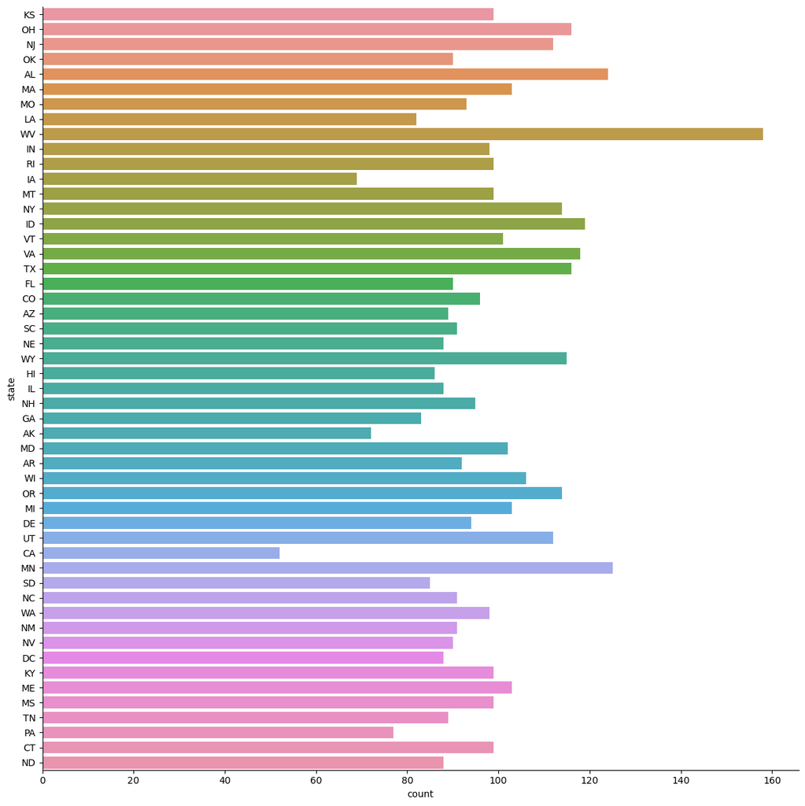

```python
sns.catplot( data = dfcc, y='state', kind='count', height=12 )

plt.show()
```

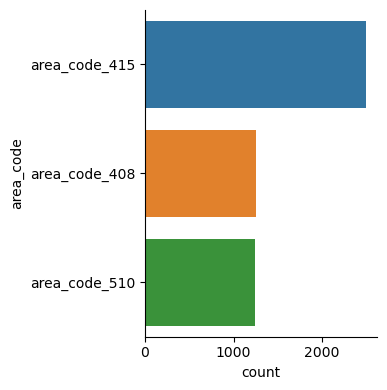

```python
sns.catplot( data = dfcc, y='area_code', kind='count', height=4 )

plt.show()
```

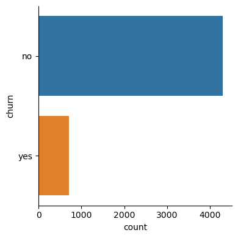

```python
sns.catplot( data = dfcc, y='churn', kind='count', height=4 )

plt.show()
```

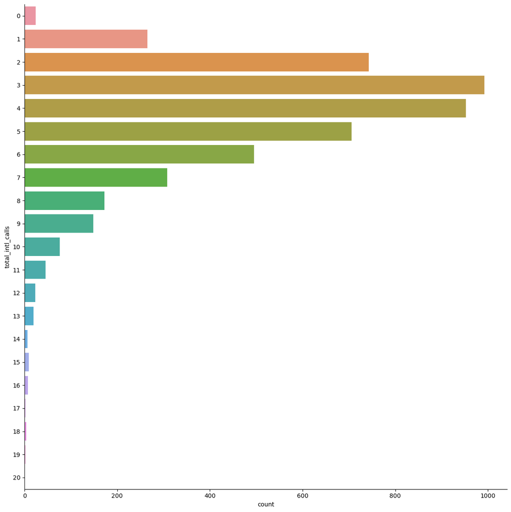

```python
sns.catplot( data = dfcc, y='total_intl_calls', kind='count', height=12 )

plt.show()
```

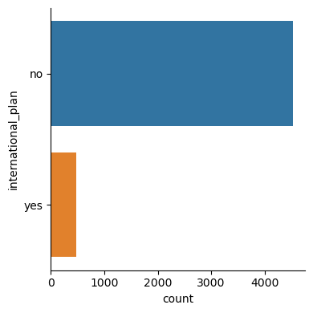

```python
sns.catplot( data = dfcc, y='international_plan', kind='count', height=4 )

plt.show()
```

## Histograms

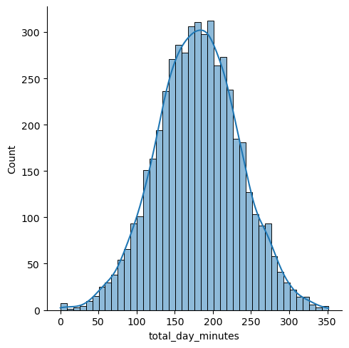

```python
sns.displot(data = dfcc, x='total_day_minutes', kind='hist', kde=True)

plt.show()
```

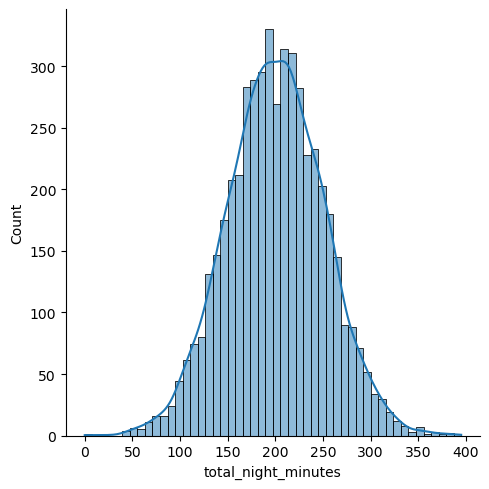

```python
sns.displot(data = dfcc, x='total_night_minutes', kind='hist', kde=True)

plt.show()
```

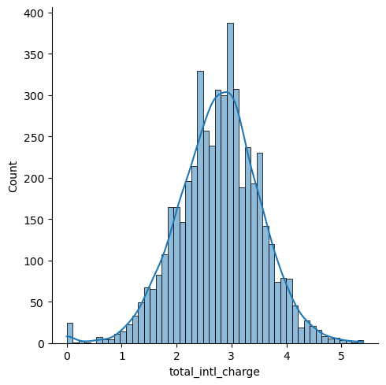

```python
sns.displot(data = dfcc, x='total_intl_charge', kind='hist', kde=True)

plt.show()
```

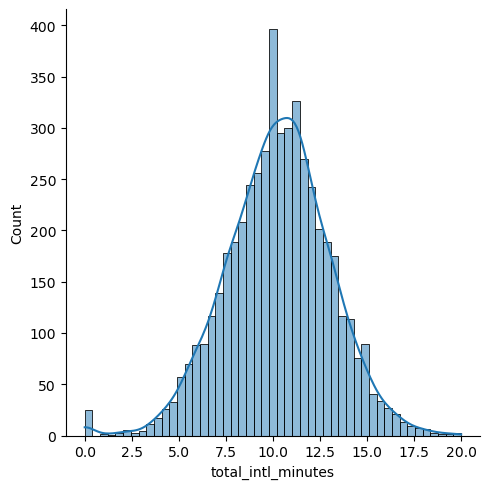

```python
sns.displot(data = dfcc, x='total_intl_minutes', kind='hist', kde=True)

plt.show()
```

## Dodged Bar Charts

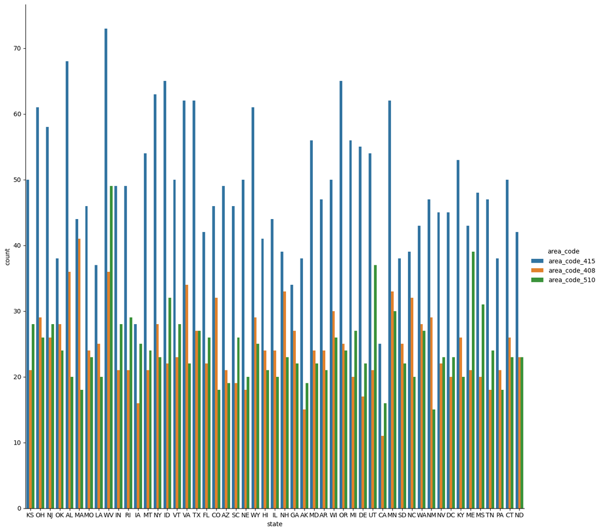

```python
sns.catplot( data = dfcc, x='state', hue='area_code', kind='count', height=12, aspect=1 )

plt.show()
```

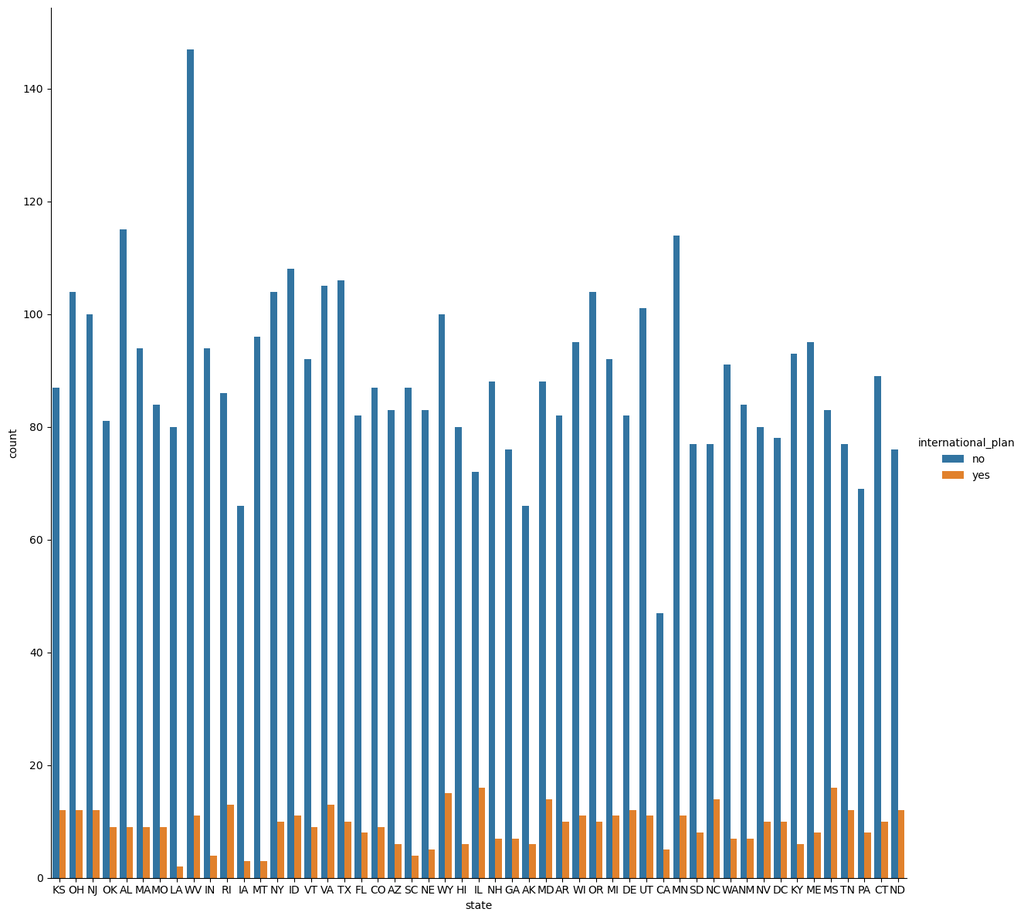

```python
sns.catplot( data = dfcc, x='state', hue='international_plan', kind='count', height=12, aspect=1 )

plt.show()
```

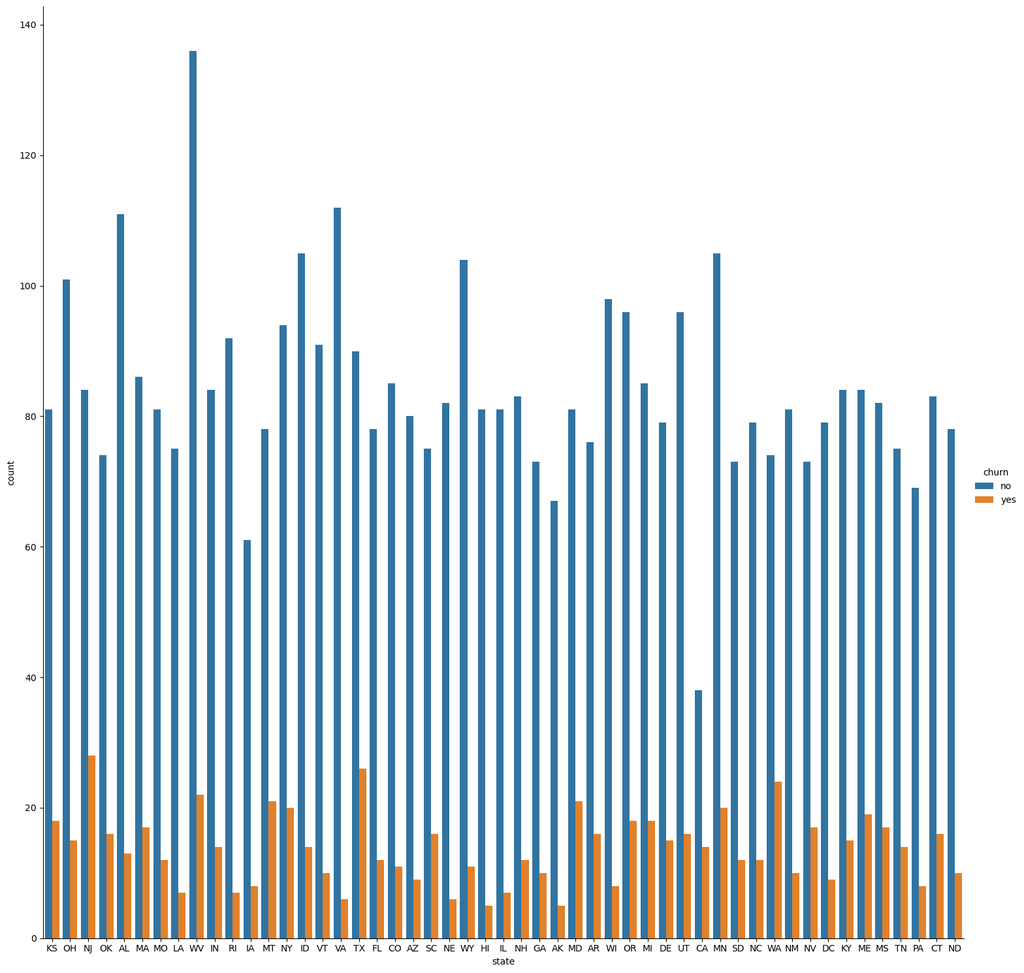

```python
sns.catplot( data = dfcc, x='state', hue='churn', kind='count', height=15, aspect=1 )

plt.show()
```

## Heat Maps

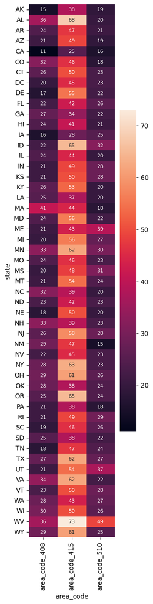

```python
fig, ax = plt.subplots(figsize=(3,15))

sns.heatmap( pd.crosstab( dfcc.state, dfcc.area_code ), ax = ax,
             annot=True, annot_kws={'size': 8}, fmt='d')

plt.show()
```

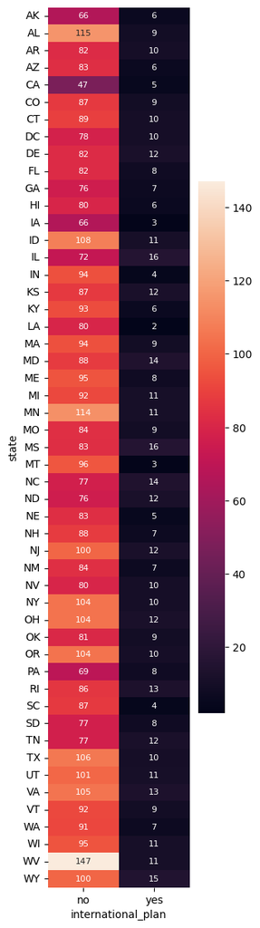

```python
fig, ax = plt.subplots(figsize=(3,15))

sns.heatmap( pd.crosstab( dfcc.state, dfcc.international_plan ), ax = ax,
             annot=True, annot_kws={'size': 8}, fmt='d')

plt.show()
```

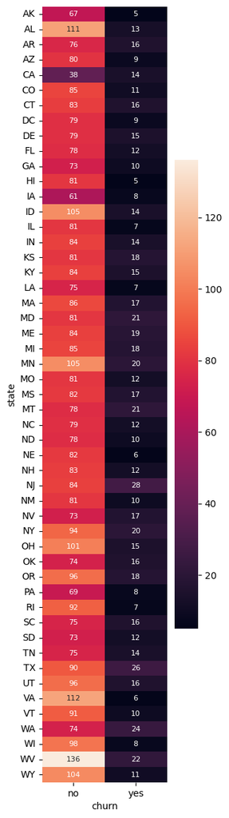

```python
fig, ax = plt.subplots(figsize=(3,15))

sns.heatmap( pd.crosstab( dfcc.state, dfcc.churn ), ax = ax,
             annot=True, annot_kws={'size': 8}, fmt='d')

plt.show()
```

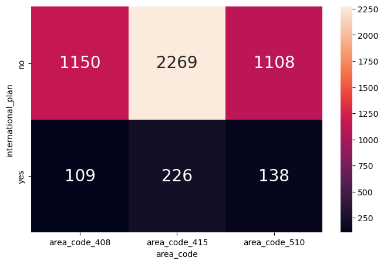

```python
fig, ax = plt.subplots(figsize=(8,5))

sns.heatmap( pd.crosstab( dfcc.international_plan, dfcc.area_code ), ax = ax,
             annot=True, annot_kws={'size': 20}, fmt='d')

plt.show()
```

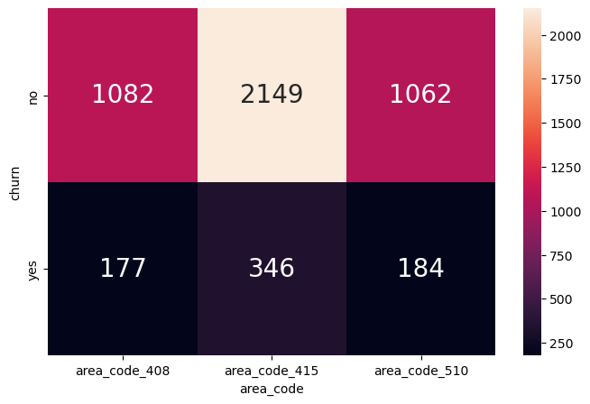

```python
fig, ax = plt.subplots(figsize=(8,5))

sns.heatmap( pd.crosstab( dfcc.churn, dfcc.area_code ), ax = ax,
             annot=True, annot_kws={'size': 20}, fmt='d')

plt.show()
```

## KDE

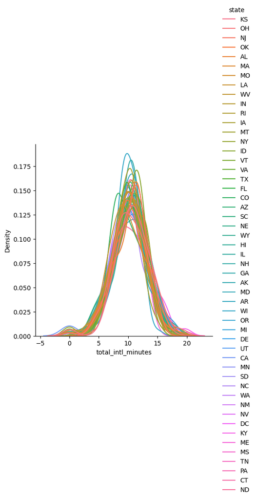

```python
sns.displot(data = dfcc, x='total_intl_minutes', hue='state',
            common_norm=False, kind='kde')

plt.show()
```

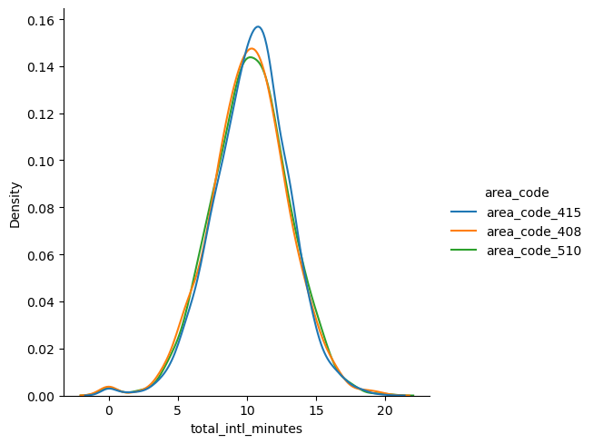

```python
sns.displot(data = dfcc, x='total_intl_minutes', hue='area_code',
            common_norm=False, kind='kde')

plt.show()
```

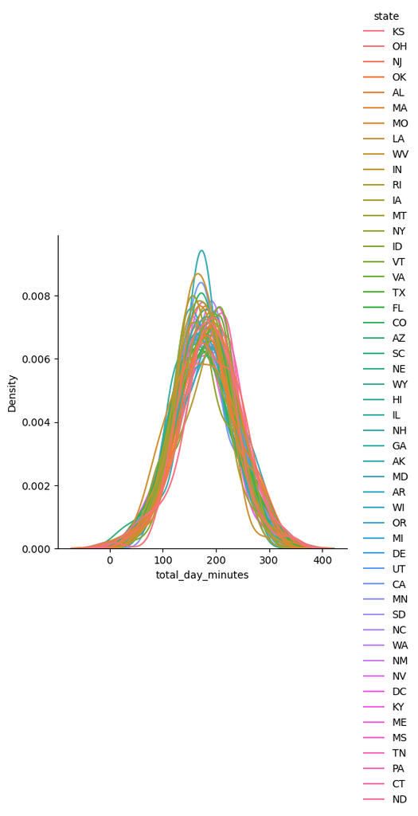

```python
sns.displot(data = dfcc, x='total_day_minutes', hue='state',
            common_norm=False, kind='kde')

plt.show()
```

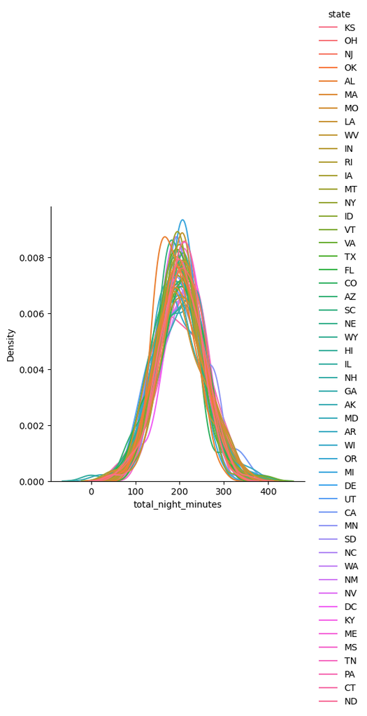

```python
sns.displot(data = dfcc, x='total_night_minutes', hue='state',
            common_norm=False, kind='kde')

plt.show()
```

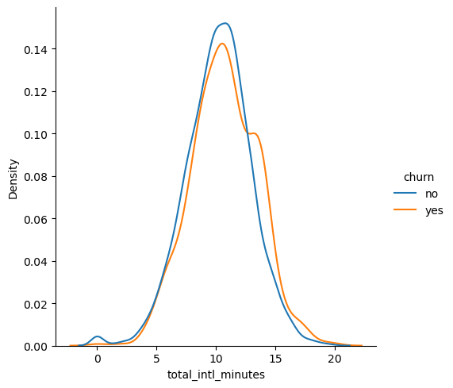

```python
sns.displot(data = dfcc, x='total_intl_minutes', hue='churn',
            common_norm=False, kind='kde')

plt.show()
```

## Boxplots

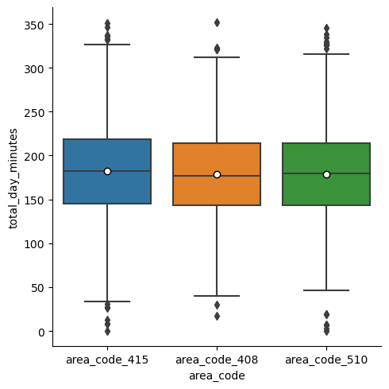

```python
sns.catplot(data = dfcc, x='area_code', y='total_day_minutes', kind='box',
            showmeans=True,
            meanprops={'marker': 'o', 'markerfacecolor': 'white', 'markeredgecolor': 'black'})

plt.show()
```

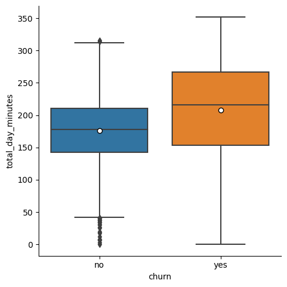

```python
sns.catplot(data = dfcc, x='churn', y='total_day_minutes', kind='box',
            showmeans=True,
            meanprops={'marker': 'o', 'markerfacecolor': 'white', 'markeredgecolor': 'black'})

plt.show()
```

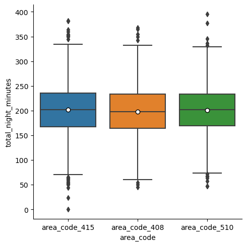

```python
sns.catplot(data = dfcc, x='area_code', y='total_night_minutes', kind='box',
            showmeans=True,
            meanprops={'marker': 'o', 'markerfacecolor': 'white', 'markeredgecolor': 'black'})

plt.show()
```

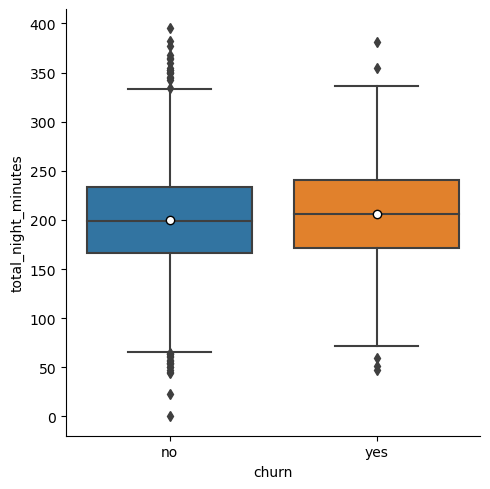

```python
sns.catplot(data = dfcc, x='churn', y='total_night_minutes', kind='box',
            showmeans=True,
            meanprops={'marker': 'o', 'markerfacecolor': 'white', 'markeredgecolor': 'black'})

plt.show()
```

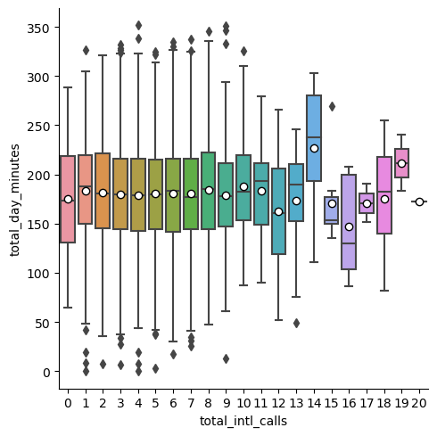

```python
sns.catplot(data = dfcc, x='total_intl_calls', y='total_day_minutes', kind='box',
            showmeans=True,
            meanprops={'marker': 'o', 'markerfacecolor': 'white', 'markeredgecolor': 'black'})

plt.show()
```

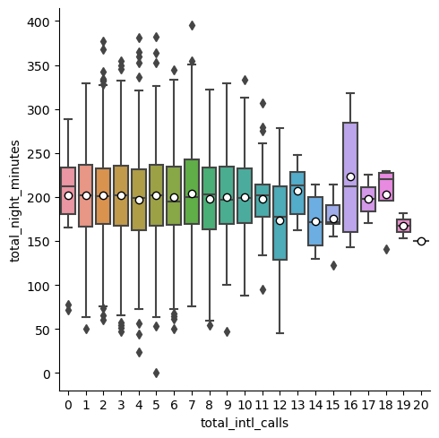

```python
sns.catplot(data = dfcc, x='total_intl_calls', y='total_night_minutes', kind='box',
            showmeans=True,
            meanprops={'marker': 'o', 'markerfacecolor': 'white', 'markeredgecolor': 'black'})

plt.show()
```

## Point Plots

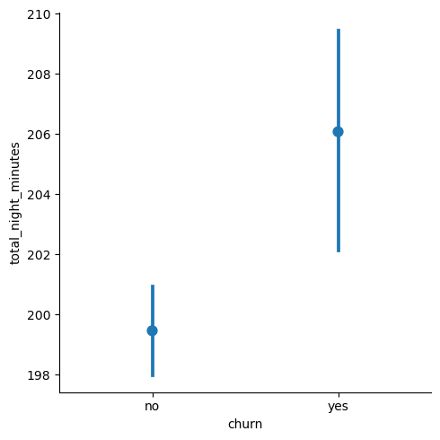

```python
sns.catplot( data = dfcc, x='churn', y='total_night_minutes', kind='point', join=False )

plt.show()
```

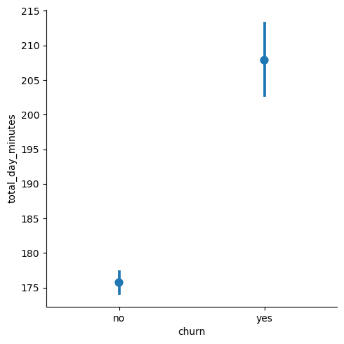

```python
sns.catplot( data = dfcc, x='churn', y='total_day_minutes', kind='point', join=False )

plt.show()
```

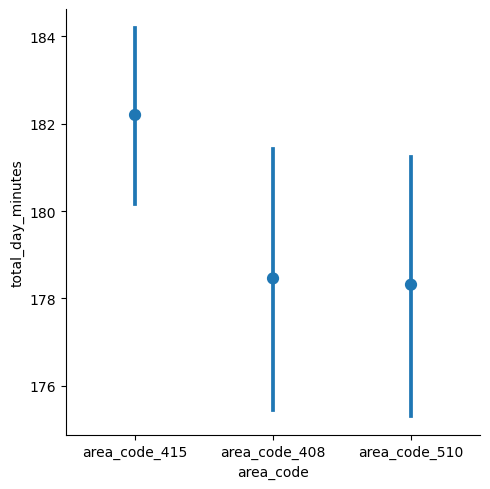

```python
sns.catplot( data = dfcc, x='area_code', y='total_day_minutes', kind='point', join=False )

plt.show()
```

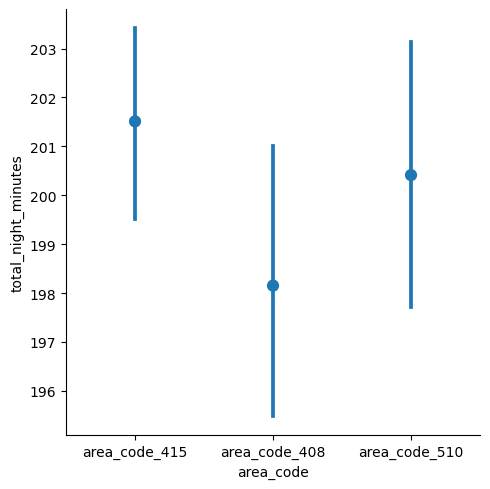

```python
sns.catplot( data = dfcc, x='area_code', y='total_night_minutes', kind='point', join=False )

plt.show()
```

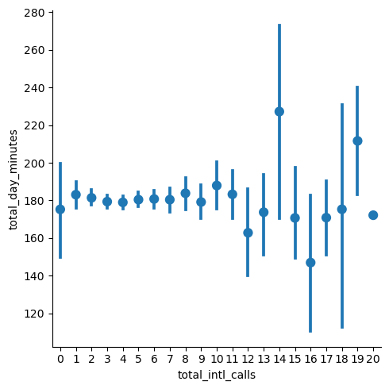

```python
sns.catplot( data = dfcc, x='total_intl_calls', y='total_day_minutes', kind='point', join=False )

plt.show()
```

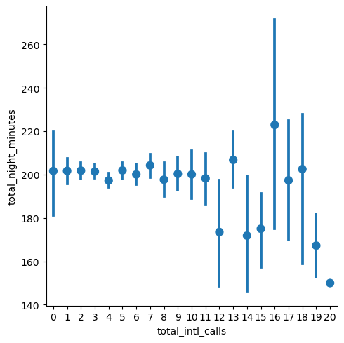

```python
sns.catplot( data = dfcc, x='total_intl_calls', y='total_night_minutes', kind='point', join=False )

plt.show()
```